# gperez_Assignment_5

Gera

9/2/2019

This is an exercise to understand K-mer-based Genomes and Transcriptomes (Part 1)

Copy or link these files to a working directory on Talapas:

```bash
scp /projects/bgmp/shared/Bi623/assign5/ssc_wgs.fastq .
scp /projects/bgmp/shared/Bi623/assign5/cha_wgs.fastq .
```

1. Using jellyfish (a k-mer counting tool), enumerate k-mers in the two data sets and format them for k-mer spectrum plotting. Use the Jellyfish/1.1.11-foss-2016b module.

```bash
#!/bin/bash

#SBATCH --account=bgmp
#SBATCH --partition=bgmp
#SBATCH --job-name=Assign_5_jellyfish
#SBATCH --output=slurm-%j-%x.out

#SBATCH --time=0-01:00:00
#SBATCH --nodes=1
#SBATCH --ntasks-per-node=1
#SBATCH --cpus-per-task=8

ml racs-eb
ml Jellyfish/1.1.11-foss-2016b


/usr/bin/time -v jellyfish count -t 8 -C -m 19 -s 5G -o 19mer_out_ssc ssc_wgs.fastq
/usr/bin/time -v jellyfish histo -o 19mer_out_ssc.histo 19mer_out_ssc_0
/usr/bin/time -v jellyfish count -t 8 -C -m 19 -s 5G -o 19mer_out_cha cha_wgs.fastq
/usr/bin/time -v jellyfish histo -o 19mer_out_cha.histo 19mer_out_cha_0
```

```r
# sets the directory to save files.
setwd("/Users/gerardoperez/Documents/shell/Bi623/Assignment5")
```

Read your ssc and cha .histo files into R Copied files to local folder on laptop to open with R-studiio.

```bash
scp hpc:/home/gperez8/bgmp/projects/bgmp/gperez8/Bi623/Ex5/*histo .
```

```r
# Opens and reads file and stores it to a variable as a dataframe.
data_txt_cha <- read.table("19mer_out_cha.histo",  header=F, row.names=1)
data_txt_ssc <- read.table("19mer_out_ssc.histo", header=F, row.names=1)


# Extracts the first 200 rows and stores them into variable
data_txt_cha_200<- data.frame(data_txt_cha[1:200,])
data_txt_ssc_200<- data.frame(data_txt_ssc[1:200,])
```

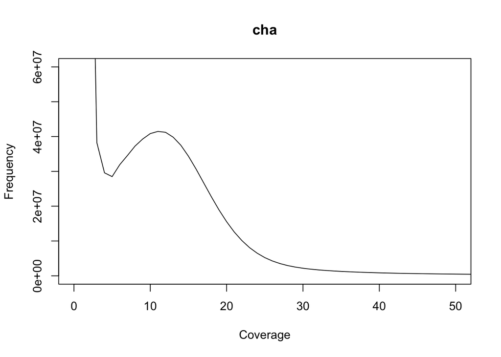

```r
# creates a scatter plot with certain parameters
plot(1:length(data_txt_cha_200[,1]), (data_txt_cha_200[,1]), type ="l", xlim=c(0,50),ylim=c(0, 6E7), xlab="Coverage", ylab="Frequency", main ="cha" )
```

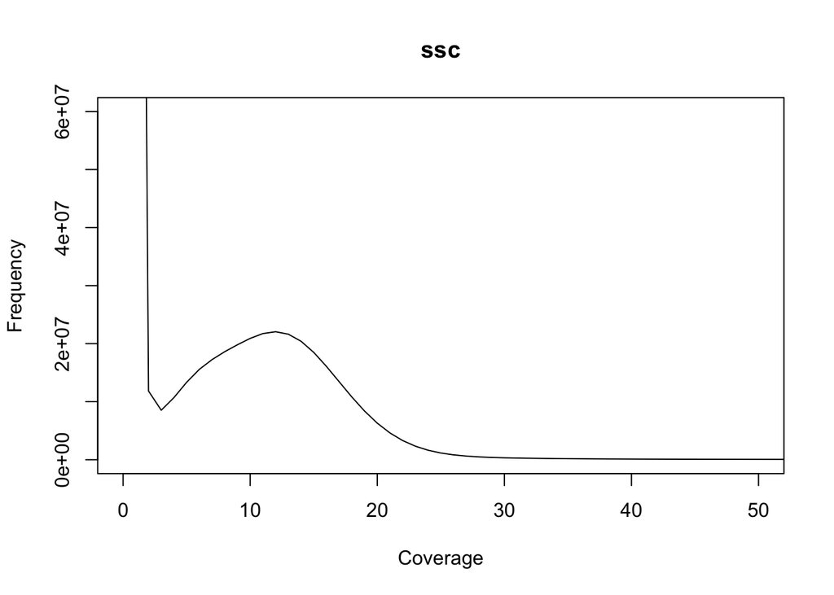

```r
# creates a scatter plot with certain parameters
plot(1:length(data_txt_ssc_200[,1]), (data_txt_ssc_200[,1]), type ="l", xlim=c(0,50),ylim=c(0, 6E7), xlab="Coverage", ylab="Frequency", main ="ssc" )
```

3 What can you infer about these two genomes based on the k-mer spectra?

4. Copy or link these files to a working directory on Talapas:

```bash
scp /projects/bgmp/shared/Bi623/assign5/SscoPEclean_R1.fastq .
scp /projects/bgmp/shared/Bi623/assign5/SscoPEclean_R2.fastq .
```

Filter the data for rare k-mers using kmer_filter, also part of the Stacks package. Perform rare k-mer filtering ONLY, and rename the new files SscoPEcleanfil_R1.fastq and SscoPEcleanfil_R2.fastq.

```bash
#!/bin/bash

#SBATCH --account=bgmp
#SBATCH --partition=bgmp
#SBATCH --job-name=kmer_filter
#SBATCH --output=slurm-%j-%x.out

#SBATCH --time=0-06:00:00
#SBATCH --nodes=1
#SBATCH --ntasks-per-node=1
#SBATCH --cpus-per-task=8
#SBATCH --mem=50G

ml easybuild  icc/2017.1.132-GCC-6.3.0-2.27  impi/2017.1.132
ml Stacks/1.46

/usr/bin/time -v kmer_filter -1 SscoPEclean_R1.fastq -2 SscoPEclean_R2.fastq -o /projects/bgmp/gperez8/projects/bgmp/gperez8/Bi623/Ex5/ --rare
```

5. Run kmer_filter again, this time to normalize the cleaned, filtered data to 2 different coverages. To save time, run these as two sbatch scripts in parallel.

Normalize to 40X k-mer coverage; compress the output files, and rename the new files SscoPEcleanfil40x_R1.fastq and SscoPEcleanfil40x_R2.fastq.

```bash
#!/bin/bash

#SBATCH --account=bgmp
#SBATCH --partition=bgmp
#SBATCH --job-name=norm_40x
#SBATCH --output=slurm-%j-%x.out

#SBATCH --time=0-06:00:00
#SBATCH --nodes=1
#SBATCH --ntasks-per-node=1
#SBATCH --cpus-per-task=8
#SBATCH --mem=50G

ml easybuild  icc/2017.1.132-GCC-6.3.0-2.27  impi/2017.1.132
ml Stacks/1.46

/usr/bin/time -v kmer_filter -1  SscoPEcleanfil_R1.fastq -2 SscoPEcleanfil_R2.fastq -o /projects/bgmp/gperez8/projects/bgmp/gperez8/Bi623/Ex5/40x  --normalize 40
```

Similarly, normalize the cleaned, filtered data to 20X k-mer coverage, compress the output files, and rename the new files SscoPEcleanfil20x_R1.fastq and SscoPEcleanfil20x_R2.fastq.

```bash
#!/bin/bash

#SBATCH --account=bgmp
#SBATCH --partition=bgmp
#SBATCH --job-name=norm_20x
#SBATCH --output=slurm-%j-%x.out

#SBATCH --time=0-06:00:00
#SBATCH --nodes=1
#SBATCH --ntasks-per-node=1
#SBATCH --cpus-per-task=8
#SBATCH --mem=50G

ml easybuild  icc/2017.1.132-GCC-6.3.0-2.27  impi/2017.1.132
ml Stacks/1.46

/usr/bin/time -v kmer_filter -1  SscoPEcleanfil_R1.fastq -2 SscoPEcleanfil_R2.fastq -o /projects/bgmp/gperez8/projects/bgmp/gperez8/Bi623/Ex5/20x  --normalize 20
```

D. Briefly explain in a sentence or two what this is doing to your data:

*Its an iteriation where this first starts by counting the occurence of each kmer read, finds the number of occurrence of each kmer, calculates the kmer coverage median for the read, discards read if median exceeds threshold and repeats the process.*

5. At this point you should have 4 sets of processed paired-end reads: Count and report the number of total read pairs for each set.

```bash
wc -l  SscoPEclean_R1.fastq
195939384 SscoPEclean_R1.fastq

wc -l  SscoPEclean_R2.fastq
195939384 SscoPEclean_R2.fastq

wc -l SscoPEcleanfil_R1.fastq
161695500 SscoPEcleanfil_R1.fastq

wc -l SscoPEcleanfil_R2.fastq
161695500 SscoPEcleanfil_R2.fastq

wc -l SscoPEcleanfil40x_R1.fastq
57304788 SscoPEcleanfil40x_R1.fastq

wc -l SscoPEcleanfil40x_R2.fastq
57304788 SscoPEcleanfil40x_R2.fastq

wc -l SscoPEcleanfil20x_R1.fastq
37606728 SscoPEcleanfil20x_R1.fastq

wc -l SscoPEcleanfil20x_R2.fastq
37606728 SscoPEcleanfil20x_R2.fastq
```

6. Now generate k-mer counts and histogram files using jellyfish (as above) 3 times - 1. on SscoPEclean_R1.fastq, 2. on SscoPEcleanfil_R1.fastq, and 3. on SscoPEcleanfil20x_R1.fastq

```bash
#!/bin/bash

#SBATCH --account=bgmp
#SBATCH --partition=bgmp
#SBATCH --job-name=R1_jellyfish
#SBATCH --output=slurm-%j-%x.out

#SBATCH --time=0-06:00:00
#SBATCH --nodes=1
#SBATCH --ntasks-per-node=1
#SBATCH --cpus-per-task=8

ml racs-eb
ml Jellyfish/1.1.11-foss-2016b


/usr/bin/time -v jellyfish count -t 8 -C -m 19 -s 5G -o SscoPEclean_R1_out SscoPEclean_R1.fastq
/usr/bin/time -v jellyfish histo -o SscoPEclean_R1_out.histo SscoPEclean_R1_out_0



/usr/bin/time -v jellyfish count -t 8 -C -m 19 -s 5G -o SscoPEcleanfil_R1_out SscoPEcleanfil_R1.fastq
/usr/bin/time -v jellyfish histo -o SscoPEcleanfil_R1_out.histo SscoPEcleanfil_R1_out_0



/usr/bin/time -v jellyfish count -t 8 -C -m 19 -s 5G -o SscoPEcleanfil20x_R1_out SscoPEcleanfil20x_R1.fastq
/usr/bin/time -v jellyfish histo -o SscoPEcleanfil20x_R1_out.histo SscoPEcleanfil20x_R1_out_0
```

Plot the spectra in R and include the figures with the rest of the assignment.

```r
# Opens and reads file and stores it to a variable as a dataframe.
data_txt_SscoPEclean_R1 <- read.table("SscoPEclean_R1_out.histo",  header=F, row.names=1)
data_txt_SscoPEcleanfil_R1 <- read.table("SscoPEcleanfil_R1_out.histo",  header=F, row.names=1)
data_txt_SscoPEcleanfil20x_R1 <- read.table("SscoPEcleanfil20x_R1_out.histo",  header=F, row.names=1)
```

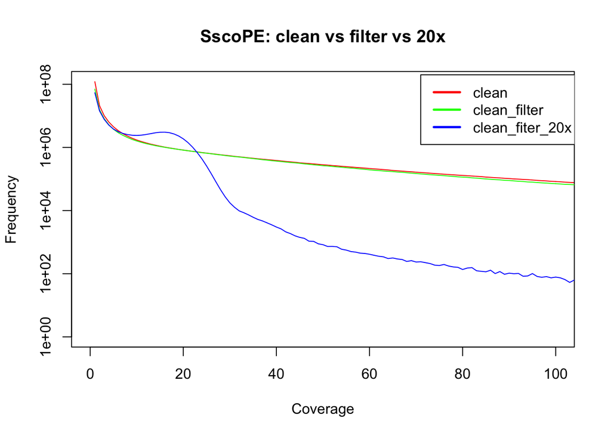

```r
# creates a scatter plot with certain parameters
plot(1:length(data_txt_SscoPEclean_R1[,1]), data_txt_SscoPEclean_R1[,1], type ="l", log= "y", xlim=c(0,100), col="red", xlab="Coverage", ylab="Frequency", main="SscoPE: clean vs filter vs 20x")

# Adds points to the scatter plot figure.
lines(1:length(data_txt_SscoPEcleanfil_R1[,1]), data_txt_SscoPEcleanfil_R1[,1], col="green")
lines(1:length(data_txt_SscoPEcleanfil20x_R1[,1]), data_txt_SscoPEcleanfil20x_R1[,1], col="blue")

# Adds legend to the plot
legend(71, 200000000,c('clean', 'clean_filter', 'clean_fiter_20x'), lwd=c(2.5,2.5),col=c("red","green", "blue"))
```

How do the 3 RNA-Seq data spectra differ? How are they different from the WGS data spectra?